# Modelling Public Water Quality Data

Matthew Ross

February 21, 2023

# Final data prep

We have a ‘tidy’ data set from our previous work that includes both discharge data and concentration data. Let’s look it! But first, where is the data?

```r
library(tidyverse) # Package with dplyr, tibble, readr, and others to help clean coding
library(dataRetrieval) # Package to download data.
library(sf) # Geospatial package to plot and explore data
library(mapview) # Simple interface to leaflet interactive maps
library(broom) # Simplifies model outputs
library(knitr) # Makes nice tables
library(kableExtra) # Makes even nicer tables
library(lubridate) # Makes working with dates easier
library(ggthemes) # Makes plots prettier
library(tidyr) # Makes multiple simultaneous models easier
library(trend) # Allows us to explore trends.
```

## Data load

```r
load('data/Q.RData')
load('data/tidied_full_wq.RData')

## Site info so we can use names rather than long site codes
colorado <- tibble(SiteID = c('USGS-09034500', 'USGS-09069000',
                           'USGS-09085000','USGS-09095500', 'USGS-09152500'),
                   basin = c('colorado1', 'eagle',
                           'roaring', 'colorado3', 'gunnison')) %>%
  bind_rows(tibble(SiteID = c('USGS-09180000', 'USGS-09180500', 'USGS-09380000'),
                          basin = c('dolores', 'colorado4', 'colorado5'))
)

# Grab the basin name
wq <- wq %>%
  inner_join(colorado)
```

## Site info extraction

```r
site.info <- whatWQPsites(siteid = unique(wq$SiteID)) %>%
  dplyr::select(SiteID = MonitoringLocationIdentifier,
                  name = MonitoringLocationName,
                  area = DrainageAreaMeasure.MeasureValue,
                  area.units = DrainageAreaMeasure.MeasureUnitCode,
                  elev = VerticalMeasure.MeasureValue,
                  elev_units = VerticalMeasure.MeasureUnitCode,
                  lat = LatitudeMeasure,
                  long = LongitudeMeasure) %>%
  distinct() %>%  # Distinct without any arguments just keeps the first of any duplicates rows
  # join this data to our `colorado` object to get the `basin` column:
  inner_join(colorado)
```

### Map

Here we use the `sf` package to project the site information data into a GIS type data object called a `simple feature (sf)`. The function `st_as_sf` converts the longitude (x) and latitude (y) coordinates into a projected point feature with the EPSG code 4326 (WGS 84). (See Lesson 1 and Lesson 4 for a more detailed explanation.) We can then use the `mapview` package and function to look at where these sites are.

```r
# convert site info as an sf object
site.sf <- site.info %>%
  st_as_sf(.,coords = c('long', 'lat'), crs = 4326)

mapview(site.sf)
```

[interactive chart not shown]

So these sites are generally in the Colorado River Basin with increasing size.

# Modelling Data

## Trend detection?

Now that we know where the data is coming from and we are happy with what it looks like, let’s start modelling! The first question we might want to explore is: **Are concentrations of elements changing over time?**. Let’s first focus on calcium in the Dolores River. As with all data work, the first thing you should do is look at our data.

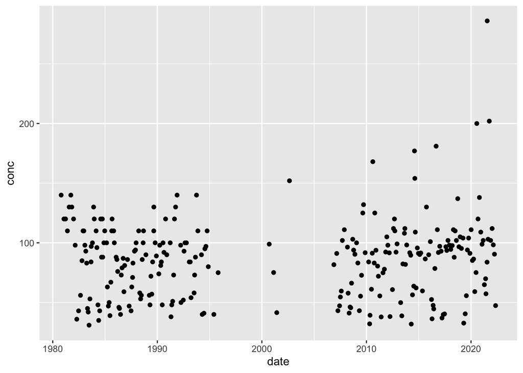

```r
dolores_ca <- wq %>%
  filter(basin == 'dolores', parameter == 'Calcium')

ggplot(dolores_ca, aes(x = date, y = conc)) +
  geom_point()
```

## Adding a trend line with ggplot

`ggplot()` has an easy method for adding a trend line to plots (`stat_smooth`()). The code below uses a linear model (lm) to fit the line:

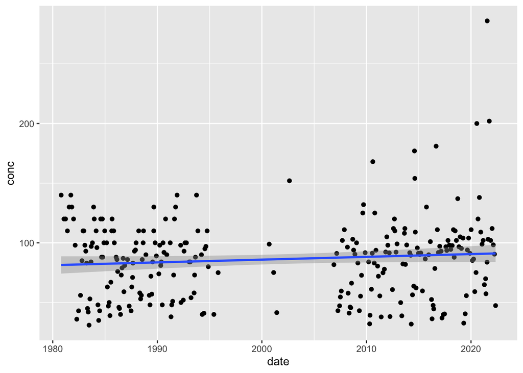

```r
ggplot(dolores_ca, aes(x = date, y = conc)) +
  geom_point() +
  stat_smooth(method = 'lm')
```

That line looks pretty flat!

### Linear models for trend detection (the wrong way).

A very intuitive way to try to detect if there is a long term trend is to use linear models, as `ggplot()` does. So, let’s go ahead and write out a model for daily calcium data using the `lm()` function. This class won’t do a great job defining when you can use linear models, but this is one of the main functions that you will use. Your stats classes should give you more background on how to use `lm()` appropriately.

```r
ca_model <- lm(conc ~ date, data = dolores_ca)
summary(ca_model)
```

```
##
## Call:
## lm(formula = conc ~ date, data = dolores_ca)
##
## Residuals:
##     Min      1Q  Median      3Q     Max
## -57.712 -27.255   2.994  16.293 195.065
##
## Coefficients:
##              Estimate Std. Error t value Pr(>|t|)
## (Intercept) 7.895e+01  5.068e+00  15.577   <2e-16 ***
## date        6.368e-04  3.997e-04   1.593    0.112
## ---
## Signif. codes:  0 '***' 0.001 '**' 0.01 '*' 0.05 '.' 0.1 ' ' 1
##
## Residual standard error: 33.24 on 260 degrees of freedom
## Multiple R-squared:  0.009666,   Adjusted R-squared:  0.005857
## F-statistic: 2.538 on 1 and 260 DF,  p-value: 0.1124
```

### The right way!

Using a linear model for trend detection breaks one of the cardinal rules of linear modelling, namely that each observation is assumed to be independent of any other observation. In a time-series like what we are looking at here, yesterday’s calcium concentration is highly correlated with today’s concentration. So linear models should never be used in trend detection. Instead we should use Mann-Kendall tests and Tau’s Sens Slope.

#### Mann-Kendall test

The Mann Kendall test is a non-parametric test of trends, you can use `?mk.test` to read more about the method, but it only requires an ordered time-series to run. Let’s use it here.

```r
dolores_ca <- dolores_ca %>%
  # Make sure data is arranged from 1980 onward.
  arrange(date)

dolores_mk <- mk.test(dolores_ca$conc)

print(dolores_mk)
```

```
##
##  Mann-Kendall trend test
##
## data:  dolores_ca$conc
## z = 1.0555, n = 262, p-value = 0.2912
## alternative hypothesis: true S is not equal to 0
## sample estimates:
##            S         varS          tau
## 1.497000e+03 2.008774e+06 4.400148e-02
```

The mk.test is really just a true/false where if the p-value is below some threshold (usually 0.05) then you can be mostly confident that there is a ‘real’ trend in the data. However it doesn’t tell you the slope of that trend. For that you need to use `sens.slope()`.

```r
dolores_slope <- sens.slope(dolores_ca$conc)
```

#### Cleaner output

The output from these models is kind of messy if you are printing lots of model results. We can use the `tidy()` function from the `broom` package to clean up this output.

```r
tidy(dolores_slope)
```

```
## # A tibble: 1 × 7
##   statistic p.value parameter conf.low conf.high method      alternative
##       <dbl>   <dbl>     <int>    <dbl>     <dbl> <chr>       <chr>
## 1      1.06   0.291       262  -0.0179    0.0675 Sen's slope two.sided
```

Some model objects don’t include both the p-value and the slope, which is slightly maddening, but we can make our own function to do this.

```r
tidier <- function(mod = dolores_slope){

  tidy(mod) %>%
    mutate(slope = mod$estimates)

}

tidier(mod = dolores_slope)
```

```
## # A tibble: 1 × 8
##   statistic p.value parameter conf.low conf.high method      alternative  slope
##       <dbl>   <dbl>     <int>    <dbl>     <dbl> <chr>       <chr>        <dbl>
## 1      1.06   0.291       262  -0.0179    0.0675 Sen's slope two.sided   0.0206
```

Ok, now we have an elaborate way to confirm what the plot already showed us. There is no long-term trend in calcium concentrations in the Dolores River.

# Models everywhere!

Okay so we have already figured out how to model data at a single site for a single parameter, but is there an efficient way to do this for ALL sites and ALL parameters?

**YES!**

I’m glad you asked. We will use the magic of `nesting` data to apply our trend models to all our data. First let’s alter the data a little to increase precision in our question.

Water chemistry is heavily controlled by seasonality and water flow, so let’s try to control for that and summarize our data to only include the low-flow periods of the year. Basically we will be focusing on: **are there trends in low flow concentrations of ions in the stream?**

```r
low_flow <- wq %>%
  mutate(month = lubridate::month(date),
         year = lubridate::year(date)) %>%
  filter(month %in% c(8,9,10,11)) %>%
  group_by(basin, SiteID, parameter, year) %>%
  summarize(conc = median(conc, na.rm = T))
```

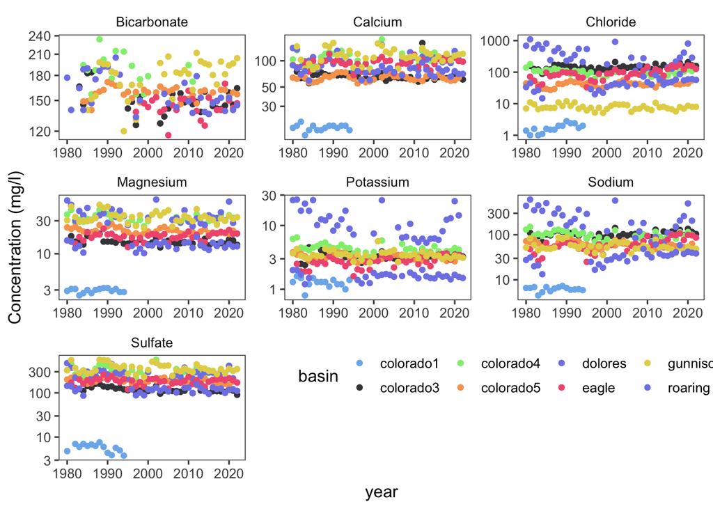

```r
ggplot(low_flow, aes(x = year, y = conc, color = basin)) +
  facet_wrap(~parameter, scales = 'free') +
  geom_point() +
  theme_few() +
  scale_y_log10() +
  scale_color_hc() +
  theme(legend.pos = c(0.7,0.2),
        legend.direction = 'horizontal') +
  ylab('Concentration (mg/l)')
```

## The Magic of Nesting

Okay, so now we have a few things:

1. A dataset that has the data organized the way we want it.
2. A function (`sens.slope()`) we can use to look at if there are long-term trends in concentration.
3. A desire to apply this function to all of our sites and parameters.

To accomplish **3** we need to use the magic of `nest()`. Nesting allows us to group data by site and parameter (like with a `group_by` and a `summarize`) and apply models to each site and parameter separately. Effectively nesting bundles (or nests!) the data into tidy little packets that we can apply the model to. Let’s try!

### Nesting data

```r
low_nest <- low_flow %>%
  # rename parameter as ion to make it more clear
  group_by(ion = parameter,basin) %>%
  nest()

head(low_nest)
```

```
## # A tibble: 6 × 3
## # Groups:   ion, basin [6]
##   basin     ion       data
##   <chr>     <chr>     <list>
## 1 colorado1 Calcium   <tibble [15 × 4]>
## 2 colorado1 Chloride  <tibble [15 × 4]>
## 3 colorado1 Magnesium <tibble [15 × 4]>
## 4 colorado1 Potassium <tibble [15 × 4]>
## 5 colorado1 Sodium    <tibble [15 × 4]>
## 6 colorado1 Sulfate   <tibble [14 × 4]>
```

### Modelling over nested data

Now we just need to apply our model to the data. To do this we need to use the `map()` function. Map takes in an x (here, our `data` column) and then a function (in this case `sens.slope()`). We use `.x$conc` to indicate that we want to apply the model to the concentration column within each bundled (nested) data frame.

```r
wq_models <- low_nest %>%
  mutate(mods = map(data, ~ sens.slope(.x$conc)))

head(wq_models)
```

```
## # A tibble: 6 × 4
## # Groups:   ion, basin [6]
##   basin     ion       data              mods
##   <chr>     <chr>     <list>            <list>
## 1 colorado1 Calcium   <tibble [15 × 4]> <htest>
## 2 colorado1 Chloride  <tibble [15 × 4]> <htest>
## 3 colorado1 Magnesium <tibble [15 × 4]> <htest>
## 4 colorado1 Potassium <tibble [15 × 4]> <htest>
## 5 colorado1 Sodium    <tibble [15 × 4]> <htest>
## 6 colorado1 Sulfate   <tibble [14 × 4]> <htest>
```

Now we have a nested data set AND nested models (that are hard to see). We can look at a single model by indexing it.

```r
# This provides the 15th model summary
wq_models$mods[15]
```

```
## [[1]]
##
##  Sen's slope
##
## data:  .x$conc
## z = 1.2567, n = 37, p-value = 0.2089
## alternative hypothesis: true z is not equal to 0
## 95 percent confidence interval:
##  -0.1857143  0.9076923
## sample estimates:
## Sen's slope
##   0.3366667
```

But that is a tedious way to look at our model summaries!

So now let’s use the power of our `tidier()` function and `unnest()`. Again, we use `map()` to apply our `tidier()` function to all of the raw `sens.slope` models, and we extract p.value and slope in a clean table. We then use `unnest()` to unravel that data so we have a final data frame that contains all of the model outputs.

```r
wq_mod_summaries <- wq_models %>%
  mutate(tidy_mods = map(mods, tidier)) %>%
  unnest(tidy_mods) %>%
  select(basin, ion, p.value, slope) %>%
  mutate(trend = ifelse(p.value < 0.01, 'yes', 'no'))

head(wq_mod_summaries)
```

```
## # A tibble: 6 × 5
## # Groups:   ion, basin [6]
##   basin     ion       p.value   slope trend
##   <chr>     <chr>       <dbl>   <dbl> <chr>
## 1 colorado1 Calcium   0.754    0      no
## 2 colorado1 Chloride  0.00320  0.09   yes
## 3 colorado1 Magnesium 0.725    0      no
## 4 colorado1 Potassium 0.247   -0.0167 no
## 5 colorado1 Sodium    0.690   -0.0308 no
## 6 colorado1 Sulfate   0.0419  -0.162  no
```

### Visualizing model output.

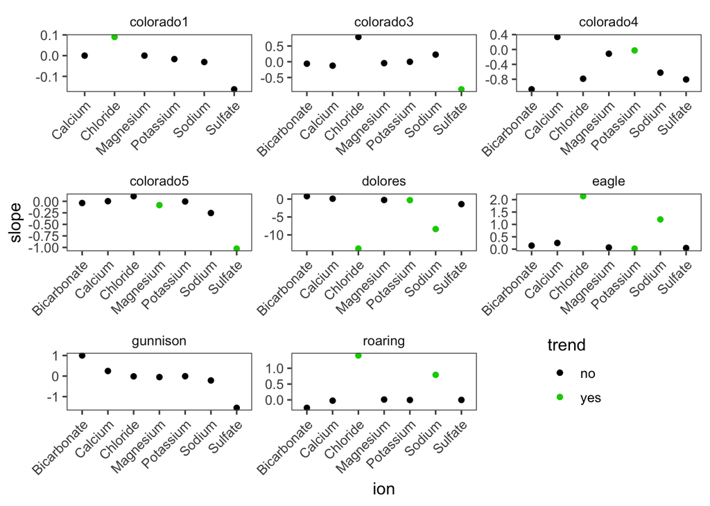

```r
ggplot(wq_mod_summaries,aes(x = ion, y = slope, color = trend)) +
  geom_point() +
  facet_wrap(~basin,scales = 'free') +
  theme_few() +
  scale_color_manual(values = c('black','green3')) +
  theme(axis.text.x = element_text(angle = 45, hjust = 1),
        legend.pos = c(0.8, 0.1))
```

# Assignment

The above workflow really focuses on trend detection, but we want to focus some on actual linear models. As such we want to join our discharge (Q) data to our water quality (WQ) data and we want to look at the relationship between Q and WQ.

## Join discharge and water quality data.

Use `inner_join()` to join our discharge data to our water quality data. You want to join by both date and siteid. Remember! the discharge data has ids that drop the `USGS-` so you will need to add that back in using a `paste()`.

Pick any site and ion combination and plot Q versus concentration. What do you see in this relationship?

Group your data by basin and ion and nest the data, use the `head()` function to print the first several rows of your nested data

## Apply a linear model to the data.

You will need to use a `map()` command like this: `map(data, ~lm(conc ~ q, data = .x))`

Summarize your data using `tidy()`. You should have a new column called `mods` or something similar and you need to “tidy” those mods.

## Visualize the data.

Make a visual of your model summaries that shows a) which sites have significant relationships between discharge and concentration, and b) the slope of that relationship.

## Bonus

Look up the `furrr` package. What does `furrr::map()` do that is different from `purrr::map()`?

When would you want to use this `furrr::` function instead of `purrr::`?